# Predicting Car Prices - Part I

1. Introduction
2. Initial Import and Setup
3. Exploratory Data Analysis (EDA)
4. Data Cleaning and Feature Extraction
5. Conclusion

# Introduction

As someone that takes the train to work everyday, I can't help but think about what car I might want to buy in the future. With that as inspiration, I built a web scraper to collect data about cars from a popular car selling website. **Part I of this project includes Exploratory Data Analysis (EDA) on the output from that web scraper, followed by some basic data cleaning and standardization.** While I won't go into detail about how I built my web scraper, it can be found on here[https://github.com/jbwebster/Data-Science-Portfolio/tree/master/Projects/CarPrices_Part1/cars_crawl.py]. This project is just as much or more about building a web scraper and processing my own data as it is about actually building the machine learning model (Part II of this project).

# Initial Import and Setup

I begin here by simply importing some useful modules for the analysis, and loading the dataset. For convenience, I've displayed the first 7 rows of the dataset below. Prior to this, I have already removed duplicates from the scraped dataset and briefly checked to make sure the web scraper worked as expected.

```python
import pandas as pd
from IPython.display import display # For displaying nicely dataframes
import matplotlib.pyplot as plt
import seaborn as sns
from sklearn.preprocessing import StandardScaler # Scale for PCA
from sklearn.decomposition import PCA
from scipy.stats import pearsonr
import re
import warnings
import numpy as np
warnings.filterwarnings('ignore')
```

```python
data = pd.read_csv('multi_combined.csv', sep=',',header=0) # Read csv into dataframe
display(data.head(7)) # Display the first 7 lines of the dataset
```

|  | Zipcode | Page | NewUsed | Year | Make | Model | MSRP | Dealer_Price | Fuel_Type | Exterior_Color | City_MPG | Interior_Color | Highway_MPG | Drivetrain | Transmission | Liters | V | Mileage | Customer_Review | URL |
| --- | --- | --- | --- | --- | --- | --- | --- | --- | --- | --- | --- | --- | --- | --- | --- | --- | --- | --- | --- | --- |
| 0 | 7097 | 1 | USED | 2016 | INFINITI | Q70 3.7X | NaN | 21495.0 | Gasoline | Black | 18.0 | Graphite | 24.0 | AWD | 7-Speed Automatic | 3.7 | 6.0 | 27344.0 | 5.0 | https://www.cars.com/vehicledetail/detail/8048... |
| 1 | 7097 | 1 | NEW | 2020 | Chevrolet | Trax LS | NaN | 20056.0 | Gasoline | Mosaic Black Metallic | 26.0 | Jet Black | 31.0 | AWD | 6-Speed Automatic | 1.4 | 6.0 | 0.0 | 4.6 | https://www.cars.com/vehicledetail/detail/7999... |
| 2 | 7097 | 1 | USED | 2016 | Hyundai | Equus Signature | NaN | 23900.0 | Gasoline | Caspian Black | 15.0 | Black | 23.0 | RWD | 8-Speed Automatic | 5.0 | 8.0 | 26641.0 | 4.8 | https://www.cars.com/vehicledetail/detail/7974... |
| 3 | 7097 | 1 | USED | 2019 | Cadillac | CT6 Luxury | NaN | 36500.0 | Gasoline | Crystal White Tri-Coat | NaN | NaN | NaN | AWD | 10-Speed Automatic | 3.6 | 6.0 | 3369.0 | 4.8 | https://www.cars.com/vehicledetail/detail/7958... |
| 4 | 7097 | 1 | USED | 2015 | Maserati | Quattroporte S Q4 | NaN | 25995.0 | Gasoline | Nero | 15.0 | Sabbia | 24.0 | AWD | 8-Speed Automatic | 3.0 | 6.0 | 36987.0 | 5.0 | https://www.cars.com/vehicledetail/detail/8078... |
| 5 | 7097 | 1 | USED | 2011 | Chrysler | Town & Country Touring | NaN | 4415.0 | E85 Flex Fuel | White | 17.0 | NaN | 25.0 | FWD | Automatic | 3.6 | 6.0 | 117007.0 | 4.8 | https://www.cars.com/vehicledetail/detail/7828... |
| 6 | 7097 | 1 | NEW | 2019 | Kia | Niro LX | NaN | 21475.0 | Hybrid | Aurora Black | 51.0 | Charcoal | 46.0 | FWD | 6-Speed Automatic with Auto-Shift | 1.6 | 6.0 | 10.0 | 4.5 | https://www.cars.com/vehicledetail/detail/7980... |

As you can see above, our scraped data includes fairly general information about the vehicles, including New/Used, the year, make and model of the car, the dealer's asking price, the interior and exterior color of the car, city and highway MPG (miles per gallon), and some basic specs about the car such as the drivetrain, transmission type, engine size, the number of miles on the car, and the overall customer rating of the car (scale of 1-5). We have a pretty even mix of continuous and categorical data types.

# Exploratory Data Analysis (EDA)

This section is in preparation for feature extraction and data cleaning. No actual data cleaning or feature extraction is done here, but this section provides the rational for how those decisions will be done in the following section.

Since the end goal of this project is to predict the Dealer_Price of a car, let's begin by simply checking how many cars are missing information about Dealer_Price.

```python
na_count = len(data) - data[['Dealer_Price']].count(axis=0)
print("Number of cars missing Dealer_Price info: " + str(na_count))
print("Percent of dataset that is missing Dealer_Price info: " + str(na_count / len(data)))
```

```
Number of cars missing Dealer_Price info: Dealer_Price    131
dtype: int64
Percent of dataset that is missing Dealer_Price info: Dealer_Price    0.044152
dtype: float64
```

It appears that about 4% of our dataset does not have information about the price of the vehicle. Since our analysis will be centered around vehicle price, these rows in our dataset won't be very useful to us. Additionally, since we scraped this data from a car selling site, it is odd that we were not able to get a price for those cars - since there would be no real point in listing the car without listing a price. It is possible that the pages that these cars were scraped from weren't formatted the way that our web scraper was expecting, so the other information about these cars may be problematic as well. We'll plan to drop those cars from our analysis before creating our machine learning model, but let's leave them in for now as we continue to explore our data. How many other missing values do we have?

```python
print("Number of Missing data values per column, given " + str(len(data)) + " rows of remaining data.")
print(len(data) - data.count(axis=0))
```

```
Number of Missing data values per column, given 2967 rows of remaining data.
Zipcode               0
Page                  0
NewUsed               0
Year                  0
Make                  0
Model                 0
MSRP               2967
Dealer_Price        131
Fuel_Type             0
Exterior_Color       36
City_MPG            373
Interior_Color      205
Highway_MPG         373
Drivetrain            1
Transmission         20
Liters              480
V                   487
Mileage             121
Customer_Review     120
URL                   0
dtype: int64
```

|  | Year | Dealer_Price | City_MPG | Highway_MPG | Liters | V | Mileage | Customer_Review |
| --- | --- | --- | --- | --- | --- | --- | --- | --- |
| count | 2967.000000 | 2836.000000 | 2594.000000 | 2594.000000 | 2487.000000 | 2480.000000 | 2846.000000 | 2847.000000 |
| mean | 2017.910347 | 25854.236248 | 24.741326 | 31.496530 | 2.630720 | 6.133871 | 19502.151792 | 4.565508 |
| std | 3.616482 | 28735.914545 | 11.114442 | 9.305346 | 1.259965 | 1.029527 | 34841.945661 | 0.349044 |
| min | 1992.000000 | 1500.000000 | 9.000000 | 11.000000 | 1.000000 | 0.000000 | 0.000000 | 1.000000 |
| 25% | 2017.000000 | 15995.000000 | 19.000000 | 26.000000 | 1.600000 | 6.000000 | 7.000000 | 4.500000 |
| 50% | 2020.000000 | 21240.000000 | 25.000000 | 31.000000 | 2.000000 | 6.000000 | 13.000000 | 4.600000 |
| 75% | 2020.000000 | 29489.000000 | 27.000000 | 35.000000 | 3.500000 | 6.000000 | 27900.000000 | 4.800000 |
| max | 2021.000000 | 859000.000000 | 140.000000 | 124.000000 | 6.800000 | 12.000000 | 268770.000000 | 5.000000 |

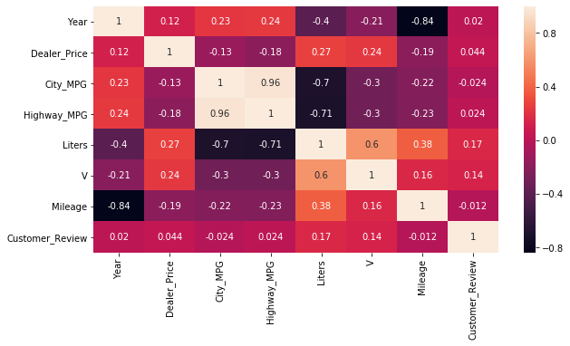

```python
# Look at correlations between quantitative variables
data_quant = data[['Year','Dealer_Price', 'City_MPG', 'Highway_MPG', 'Liters', 'V', 'Mileage', 'Customer_Review']]
plt.figure(figsize=(10,5))
c= data_quant.corr()
sns.heatmap(c,annot=True)

data_quant.describe()
```

Many of the correlations that we see here seem fairly intuitive and help us confirm the validity of our scraped data. For example, City_MPG and Highway_MPG have an extremely high, positive correlation, but both of them are negatively correlated with larger engine sizes. Predictably, newer cars (by Year) have less Mileage. Interestingly, the strongest correlations to Dealer_Price that we see are to the size of the engine. In fact, the list price of the car correlates better with the size of the engine than it does with how new the car is or even how many miles the car has. We also see that Customer_Reviews (on a scale of 1-5) have very little correlation with anything.

An alternative way of viewing similar information in a more graphical way, might look like the plot below.

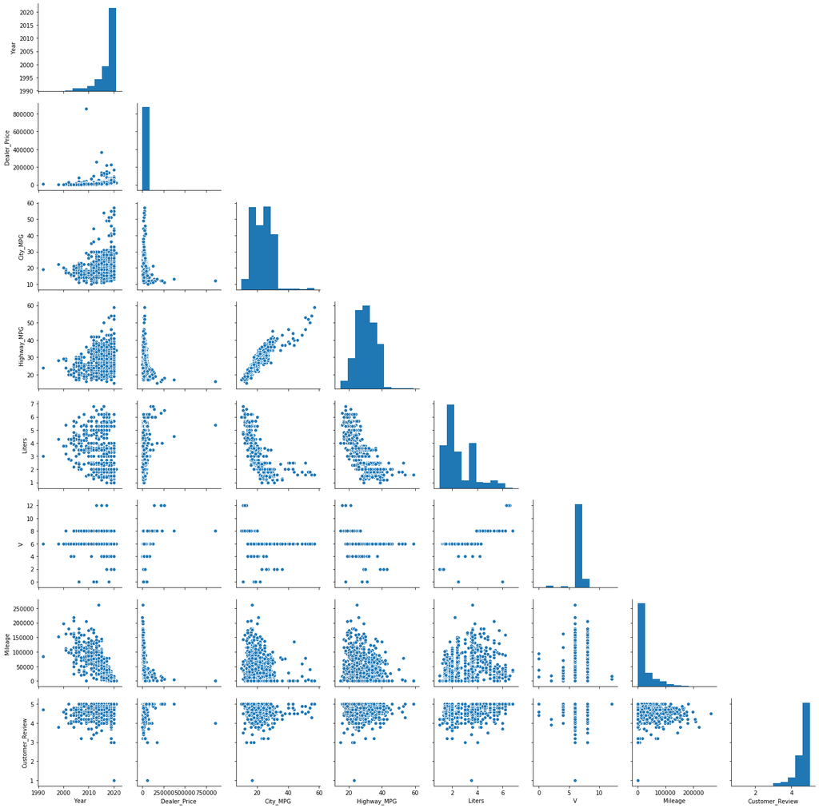

```python
data_quant_noNA = data_quant.dropna()

# SHOW BOTTOM TRIANGLE ONLY
def hide_current_axis(*args, **kwds):
    plt.gca().set_visible(False)

g = sns.pairplot(data_quant_noNA)
g.map_upper(hide_current_axis);
```

The plots here make it easier to visualize the descriptive statistics that were printed above. This method also makes it clear that we have some potential outliers. In particular, I am most concerned about the outlier seen in the Dealer_Price section, especially since that is the variable we are trying to predict, yet that particular vehicle doesn't appear to be an outlier in any other category besides price. We also have a somewhat obvious outlier in the Customer_Review section. I've printed the two potential outliers below, as well as boxplots to better represent how they compare to the rest of the data.

|  | Zipcode | Page | NewUsed | Year | Make | Model | MSRP | Dealer_Price | Fuel_Type | Exterior_Color | City_MPG | Interior_Color | Highway_MPG | Drivetrain | Transmission | Liters | V | Mileage | Customer_Review | URL |
| --- | --- | --- | --- | --- | --- | --- | --- | --- | --- | --- | --- | --- | --- | --- | --- | --- | --- | --- | --- | --- |
| 653 | 70032 | 4 | NEW | 2020 | Ford | Expedition Max XLT | NaN | 58522.0 | Gasoline | Star White | 17.0 | Ebony | 23.0 | RWD | 10-Speed Automatic | 3.5 | 6.0 | 30.0 | 1.0 | https://www.cars.com/vehicledetail/detail/7989... |
| 208 | 7097 | 3 | USED | 2009 | Mercedes-Benz | SLR McLaren | NaN | 859000.0 | Gasoline | NaN | 12.0 | NaN | 16.0 | RWD | 5-Speed Automatic | 5.4 | 8.0 | 1379.0 | 4.0 | https://www.cars.com/vehicledetail/detail/8038... |

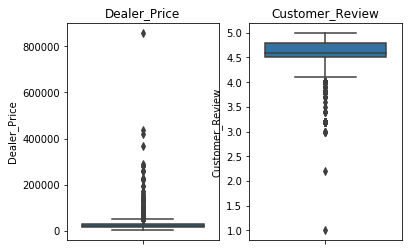

```python
index1 = data['Customer_Review'].idxmin()
index2 = data['Dealer_Price'].idxmax()
outliers_df = data.loc[[index1 , index2] , : ]
display(outliers_df)
fig, (ax1, ax2) =plt.subplots(1,2)
sns.boxplot(y="Dealer_Price", data=data, ax=ax1).set_title("Dealer_Price");
sns.boxplot(y="Customer_Review", data=data, ax=ax2).set_title("Customer_Review");
fig.show();
```

These two definitely look like outliers, and even worse, the rest of the data looks fairly typical, which means it would be very difficult for our future machine learning model to interpret these vehicles accurately. We can also see that there are a few other vehicles that could potentially be seen as outliers. I've chosen to keep them for now, mainly out of curiosity to see how well our model will be able to handle them. Remember, this is just a side project, not production ready code, so there is a pretty minimal downside to including them in our analysis for now.

Now that we've confirmed that the quantitative data seems to have the trends we would expect, made plans to remove outliers, and seen the distributions of those variables, let's move on to the categorical data types. First, how many different Makes do we have?

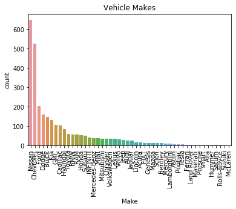

```python
data_categorical = data[['NewUsed', 'Make', 'Model', 'Fuel_Type', \
                         'Exterior_Color', 'Interior_Color', 'Drivetrain', 'Transmission' ]]

chart = sns.countplot(x="Make", data=data_categorical,\
              order = data_categorical['Make'].value_counts().index)

chart.set_xticklabels(chart.get_xticklabels(), rotation=90)
chart.set_title("Vehicle Makes")
plt.show()
```

```python
print("Number of unique Model types: " + str(len(data.Model.unique())))
print("Total number of vehicles: " + str(len(data)))
Model_counts = data['Model'].value_counts()
print(Model_counts[1:5])
print(Model_counts[-5:])
```

```
Number of unique Model types: 924
Total number of vehicles: 2967
Rogue SV        86
Versa S         73
Kicks SV        68
Versa 1.6 SV    67
Name: Model, dtype: int64
F430 Berlinetta    1
F12berlinetta      1
Altima 2.5 SL      1
GS 350 Base        1
440i               1
Name: Model, dtype: int64
```

Similar to the Model column in our data, it is unclear how usable the Interior_Color and Exterior_Color columns will be in their original format. Most manufacturers use custom color names for their paint and interiors. To get a better idea of color name overlaps, I've printed the number of unique color names below.

```python
print("Number of unique exterior colors in original data: " + str(len(data.Exterior_Color.unique())))
print("Number of unique interior colors in original data: " + str(len(data.Interior_Color.unique())))
```

```
Number of unique exterior colors in original data: 618
Number of unique interior colors in original data: 238
```

There actually seems to be quite a bit more overlap in the interior color names than there is in the exterior color names, but either way, we'll probably want to try to extract information from the names so we can group similar colors together.

How does the Transmission data look?

```python
print(data['Transmission'].value_counts())
```

```
Automatic CVT                        775
6-Speed Automatic                    671
Automatic                            513
8-Speed Automatic                    220
9-Speed Automatic                    198
4-Speed Automatic                    107
Variable                              74
10-Speed Automatic                    68
1-Speed Automatic                     51
5-Speed Automatic                     49
7-Speed Automatic with Auto-Shift     48
7-Speed Automatic                     45
6-Speed Automatic with Auto-Shift     41
6-Speed Manual                        29
5-Speed Manual                        23
Manual                                 9
AUTO                                   4
8-Speed Automatic with Auto-Shift      2
6-Speed                                2
Automatic, Xtronic CVT                 2
Automatic, 6-Spd                       2
Automatic, CVT                         1
6-Speed Automatic with Overdrive       1
3-Speed Manual                         1
6-Speed Automatic w/OD                 1
Automanual                             1
Auto, CVT w/Xtronic                    1
Auto, 6-Spd Overdrive                  1
Autoamtic                              1
Automatic, 6-Spd w/Overdrive           1
5-Speed Automatic with Auto-Shift      1
7-Speed DSG Automatic                  1
Automatic, 5-Spd                       1
Auto, 6-Spd SelectShift                1
9-Speed Automatic with Auto-Shift      1
Name: Transmission, dtype: int64
```

It seems like it might actually be worth splitting this column into multiple columns. In one column, we could have the numeric 'speed' value for the transmission, and we could list whether it is Automatic or Manual in a different location. We could also consider creating another column to list whether or not the car has 'Auto-Shift'.

How does the Drivetrain data look?

```python
print(data['Drivetrain'].value_counts())
```

```
FWD                  1687
AWD                   679
4WD                   320
RWD                   271
4X4                     5
4x2/2-wheel drive       2
2WD                     1
4x4/4-wheel drive       1
Name: Drivetrain, dtype: int64
```

What about fuel type?

```python
print(data['Fuel_Type'].value_counts())
display(data[data['Fuel_Type'] == "Unknown"])
```

```
Gasoline         2718
Hybrid            102
E85 Flex Fuel      75
Diesel             47
Electric           24
Unknown             1
Name: Fuel_Type, dtype: int64
```

|  | Zipcode | Page | NewUsed | Year | Make | Model | MSRP | Dealer_Price | Fuel_Type | Exterior_Color | City_MPG | Interior_Color | Highway_MPG | Drivetrain | Transmission | Liters | V | Mileage | Customer_Review | URL |
| --- | --- | --- | --- | --- | --- | --- | --- | --- | --- | --- | --- | --- | --- | --- | --- | --- | --- | --- | --- | --- |
| 1674 | 92602 | 4 | USED | 2006 | Volkswagen | Touareg V6 | NaN | 4995.0 | Unknown | Blueish | 16.0 | Black | 21.0 | 4X4 | Automatic | 3.2 | 6.0 | 166698.0 | 4.4 | https://www.cars.com/vehicledetail/detail/8015... |

Again, this seems fairly well organized, with only a single car being in the 'Unknown' category. Above, I printed the car with an 'Unknown' fuel type, and found that it was a Volkswagen Touareg V6. After a quick Google search, it appears that that vehicle uses Gasoline. So I will want to update that when the time comes.

The final categorical variable that we haven't looked at is zipcode.

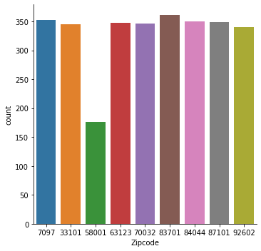

```python
sns.catplot(x="Zipcode", kind="count", data=data)
```

Cars appear to be evenly distributed across the zipcodes in our dataset (which is what the web crawler was designed to do). We appear to have about half as many vehicles from 58001 however - there may have been some sort of temporary error with my connection to their website when I was scraping data about vehicles from that zipcode, causing the web crawler to quit. In any case, with everything else being approximately uniformly distributed, I'm not particularly worried about that missing data for this side project. We will, however, want to represent this data in a slightly different way, since we wouldn't want our model to treat zipcodes as numeric values (but rather as discrete groups).

Now, there are dozens of ways we could continue our EDA, by seeing how the different variables interact. Do certain zipcodes have higher prices? Are colorful cars more expensive? Are certain Makes or Models more common in some locations? What's the most popular interior/exterior color combo? Perhaps we could save this dataset and do further exploration as some sort of future micro-project. For the time being, I think we are ready to start with our feature extraction and data cleaning in preparation for making our predictive model.

# Data Cleaning and Feature Extraction

There is probably more we can do, but that seems like a decent list for our purposes.

Here, we do steps 1 and 2 by dropping the desired vehicles.

```python
# Drop values that are missing dealer price information
data_mod = data.dropna(subset=['Dealer_Price'])

# Drop the two most extreme outliers for price and customer review
index1 = data['Customer_Review'].idxmin()
index2 = data['Dealer_Price'].idxmax()
data_mod = data_mod.drop(axis=0, index=[index1, index2], inplace = False)
```

We'll now work to group together our vehicle makes. To review what they were, I've printed them below.

```python
print(data_mod['Make'].unique())
```

```
['INFINITI' 'Chevrolet' 'Hyundai' 'Cadillac' 'Maserati' 'Chrysler' 'Kia'
 'BMW' 'Toyota' 'Audi' 'Volkswagen' 'GMC' 'Mercury' 'Nissan' 'Buick'
 'Rolls-Royce' 'Jaguar' 'Lexus' 'Mercedes-Benz' 'Acura' 'Subaru' 'Honda'
 'Genesis' 'Land Rover' 'Mazda' 'Aston' 'Ferrari' 'Pontiac' 'Mitsubishi'
 'Dodge' 'Volvo' 'Lamborghini' 'smart' 'RAM' 'Lincoln' 'Ford' 'Bentley'
 'Scion' 'FIAT' 'McLaren' 'Jeep' 'Hummer' 'Saturn' 'MINI' 'Alfa' 'Porsche'
 'Suzuki' 'Tesla']
```

There are a few ways we could group these together. We could try to group them by function (daily drivers, luxury, sports cars), by popularity (ranked by how many are in the dataset), or some other distinguisher. One metric might be the mean price of each Make, but it doesn't really seem like good practice to use the price as a way to group things (making a variable determined strictly by price, and then using that variable to predict price would be circular logic). In an effort to 1) avoid the circular logic and 2) have some sort of data-driven approach rather than random arbitrary choice, **I have elected to group them based on how common they are in the dataset.** This is likely to relate to price, but not specifically in a direct way, and makes it so I don't have to arbitrarily make the decisions.

```python
make_counts = data_mod['Make'].value_counts() # Count the number of times each make appears
n = len(make_counts)
makes = list(make_counts.index) # List of makes, in order of how often the appear

threshold1 = int(n/4)
threshold2 = threshold1 * 2
threshold3 = threshold1 * 3


tier_1 = makes[0:threshold1] # Makes that are in the first 1/4 of the ordered list
tier_2 = makes[threshold1:threshold2] # Makes that rank between 1/4 and the middle of the list
tier_3 = makes[threshold2:threshold3] # Makes that rank from the middle of the list to the last quarter of the list
tier_4 = makes[threshold3:] # Makes that are ranked in the last quarter of the list
print("Tier 1: ")
print(tier_1)
print("Tier 2: ")
print(tier_2)
print("Tier 3: ")
print(tier_3)
print("Tier 4: ")
print(tier_4)

# Incorporate these groupings into our data
make_dict = {}
for make in tier_1:
    make_dict[make] = "Tier_1"
for make in tier_2:
    make_dict[make] = "Tier_2"
for make in tier_3:
    make_dict[make] = "Tier_3"
for make in tier_4:
    make_dict[make] = "Tier_4"
data_mod = data_mod.assign(
    Make_Tier = lambda data_mod: data_mod['Make'].map(lambda Make: make_dict[Make])
)
```

```
Tier 1:
['Nissan', 'Chevrolet', 'Ford', 'Dodge', 'Buick', 'Kia', 'GMC', 'Cadillac', 'Hyundai', 'Honda', 'RAM', 'Toyota']
Tier 2:
['Subaru', 'BMW', 'INFINITI', 'Mitsubishi', 'Chrysler', 'Volkswagen', 'Mercedes-Benz', 'Lexus', 'Jeep', 'Volvo', 'Audi', 'Jaguar']
Tier 3:
['Lincoln', 'Acura', 'MINI', 'Genesis', 'Mazda', 'Scion', 'FIAT', 'Bentley', 'Mercury', 'Lamborghini', 'Pontiac', 'Tesla']
Tier 4:
['Ferrari', 'Maserati', 'Aston', 'Porsche', 'smart', 'Land Rover', 'Alfa', 'Saturn', 'Hummer', 'Rolls-Royce', 'Suzuki', 'McLaren']
```

We can see from the above printed lists that even though we only used the data from the Make column of our dataset in order to group cars together, we managed to get several common, daily-driver type cars in 'Tier 1', while 'Tier 4' is most luxury/sports vehicles. This seems like an effective way to group the cars, without making unnecessary assumptions, or incorporating other data.

Step 4 was to drop the information in the 'Model' column. We could just tell our machine learning model to ignore that column, but for clarity, I'll drop it here.

```python
data_mod = data_mod.drop(columns='Model')
```

Step 5 was to simplify and group together the information we have about car colors, since most manufacturers use custom names to describe their car colors.

```python
# Identify the base color of the custom name colors
root_colors = ['silver','white','black', 'red', \
               'gray','yellow','orange', 'blue', \
              'metallic', 'pearl', 'grey', 'granite', \
              'clearcoat', 'scarlet', 'graphite', \
              'green', 'emerald', 'crimson', 'brown', 'charcoal', 'beige', 'ebony']
pattern = '|'.join(root_colors)


def pattern_searcher(search_str:str, search_list:str):
    if not isinstance(search_str, str):
        return 'NA'
    search_str = search_str.lower()
    search_obj = re.search(search_list, search_str)
    if search_obj :
        return_str = search_str[search_obj.start(): search_obj.end()]
        if return_str == "pearl":
            return_str = "white"
        elif return_str == "grey" or return_str == "granite":
            return_str = "gray"
        elif return_str == "clearcoat" or return_str == "graphite":
            return_str = "silver"
        elif return_str == "scarlet" or return_str == "crimson":
            return_str = "red"
        elif return_str == "emerald":
            return_str = "green"
        elif return_str == 'charcoal' or return_str == 'ebony':
            return_str = "black"
        elif return_str == 'beige':
            return_str = "brown"


    else:
        return_str = 'OTHER'
    return return_str

n = len(data_mod['Exterior_Color'].unique())
print("Number of unique exterior colors in original data: " + str(n))
data_mod['Standard_Ext_Color'] = data_mod['Exterior_Color'].apply(lambda x: pattern_searcher(search_str=x, search_list=pattern))
print("After standardization:")
print(data_mod['Standard_Ext_Color'].value_counts())
n = len(data_mod['Interior_Color'].unique())
print("Number of unique interior colors in original data: " + str(n))
data_mod['Standard_Int_Color'] = data_mod['Interior_Color'].apply(lambda x: pattern_searcher(search_str=x, search_list=pattern))
print(data_mod['Standard_Int_Color'].value_counts())

# Drop the now unnecessary Exterior_Color and Interior_Color columns
data_mod = data_mod.drop(columns = ['Exterior_Color', 'Interior_Color'])
```

```
Number of unique exterior colors in original data: 586
After standardization:
white       673
black       591
silver      385
metallic    273
gray        244
red         232
blue        218
OTHER       107
NA           35
green        27
orange       27
brown        20
yellow        2
Name: Standard_Ext_Color, dtype: int64
Number of unique interior colors in original data: 225
black     1798
OTHER      355
gray       254
NA         201
brown      107
silver      89
red         21
white        5
blue         2
orange       2
Name: Standard_Int_Color, dtype: int64
```

While our method isn't ideal, we were able to convert the 586 unique names for exterior colors into about a dozen different basic colors, with only a fraction of our dataset being listed as 'OTHER' (we weren't sure what it was) or 'NA' (the data was missing to begin with). We also converted the 225 unique interior colors into some standard colors as well, although we were a little less successful there. I have manually gone through the list of interior colors, and many of them are unique enough that it would take me quite a bit of Googling to figure out what those colors actually are - so I've opted to leave it with this sub-optimal standardization.

The sixth thing we wanted to do was to split our Transmission data into two different columns. Here, I've used a very similar approach to what I used for standardizing colors.

```python
def transmission_pattern_searcher(search_str:str):
    if not isinstance(search_str, str):
        return 'NA'
    search_str = search_str.lower()
    search_obj = re.search("auto", search_str)
    if search_obj:
        tran_type = 'automatic'
    else:
        search_obj = re.search("variable", search_str)
        if search_obj:
            tran_type = "variable"
        else:
            tran_type = 'manual'
    return tran_type

def gears_searcher(search_str:str):
    if not isinstance(search_str, str):
        return 'NA'
    gears_obj = re.search("[\d]+", search_str)
    if gears_obj:
        gears = re.search("[\d]+", search_str)[0]
    else:
        gears = 'NA'
    return gears

data_mod['Transmission_Type'] = data_mod['Transmission'].apply(lambda x: transmission_pattern_searcher(search_str=x))
data_mod['Gears'] = data_mod['Transmission'].apply(lambda x: gears_searcher(search_str=x))
data_mod = data_mod.drop(columns=['Transmission'])
```

Step 7: Standarize our drivetrain data.

```python
data_mod.loc[data_mod.Drivetrain == "4x4", "Drivetrain"] = "4WD"
data_mod.loc[data_mod.Drivetrain == "4x2/2-wheel drive", "Drivetrain"] = "FWD"
data_mod.loc[data_mod.Drivetrain == "2WD", "Drivetrain"] = "FWD"
data_mod.loc[data_mod.Drivetrain == "4x4/4-wheel drive", "Drivetrain"] = "4WD"
```

Step 8-9: Fill in an 'Unknown' value in the 'Fuel_Type' column, and convert Zipcode values into strings.

```python
data_mod.loc[data_mod.Fuel_Type == "Unknown", "Fuel_Type"] = "Gasoline"
data_mod['Zipcode'] = data_mod['Zipcode'].apply(str)
```

```python
data_mod['City_MPG'] = data_mod['City_MPG'].fillna((data_mod['City_MPG'].median()))
data_mod['Highway_MPG'] = data_mod['Highway_MPG'].fillna((data_mod['Highway_MPG'].median()))
data_mod['Liters'] = data_mod['Liters'].fillna((data_mod['Liters'].median()))
data_mod['V'] = data_mod['Liters'].fillna((data_mod['Liters'].median()))

# Save our cleaned data for future use
filename = "cleaned_car_data.csv"
data_mod.to_csv (r'cleaned_car_data.csv', index = False, header=True)
```

# Conclusion

That should do it! We've scraped data from a public website, done some Exploratory Data Analysis, and taken some simple, basic steps to clean and standardize our data. We can now take this data and attempt to build a machine learning model for predicting car prices based on the data we've collected, which can be found in Part II of this project.